# Machine Learning Project

This assignment is based on the work done by Velloso, E.; Bulling, A.; Gellersen, H.; Ugulino, W.; Fuks, H. Qualitative Activity Recognition of Weight Lifting Exercises. Proceedings of 4th International Conference in Cooperation with SIGCHI (Augmented Human ’13) . Stuttgart, Germany: ACM SIGCHI, 2013

Read more: http://groupware.les.inf.puc-rio.br/har#ixzz5KiZnE8Ua

## Load Necessary Packages

```r
suppressPackageStartupMessages(library(caret))
suppressPackageStartupMessages(library(mboost))
suppressPackageStartupMessages(library(dplyr))
suppressPackageStartupMessages(library(parallel))
suppressPackageStartupMessages(library(doParallel))
```

## Load Data

```r
#Load data if cached
  if(file.exists("data/training.csv")){
    training <- as_tibble(read.csv(file = "data/training.csv"))
  }
  # Download source data
  if(!dir.exists("data")) dir.create("data")
  if(!file.exists("data/training.csv")) {
    download.file("https://d396qusza40orc.cloudfront.net/predmachlearn/pml-training.csv", "data/training.csv")
    training <- as_tibble(read.csv(file = "data/training.csv"))
  }
  if(file.exists("data/testing.csv")){
    training <- as_tibble(read.csv(file = "data/training.csv"))
  }
  if(!dir.exists("data")) dir.create("data")
  if(!file.exists("data/testinging.csv")) {
    download.file("https://d396qusza40orc.cloudfront.net/predmachlearn/pml-testing.csv", "data/testing.csv")
  }
```

## Explore Data

Attemp to reduce the dimensionality. Looking at the data it seems like a lot of the rows have NAs. Let’s see how they are distributed.

```r
percentNa <- function(x){ sum(is.na(x))/length(x)}
table(apply(training, 2, percentNa))
```

```
                0 0.979308938946081
               93                67
```

Let’s just drop the columns that are mostly NAs.

```r
training[, c(apply(training,2,percentNa)< 0.5)] -> reducedtraining
```

## More Exploration

Tried to do a random forest on the entire set, but could not get analysis to complete. Even after parallalizing the datat. Maybe I can try and reduce the dimensionality a little more, and look at some of the subsets. There are groups of data named belt, arm, forearm, dumbell. Lets see if any of those are interesting.

```r
reducedtraining %>% select(contains("_belt")) %>% select_if(is.numeric) %>% mutate(classe = reducedtraining$classe) -> beltdata
reducedtraining %>% select(contains("_arm")) %>% select_if(is.numeric) %>% mutate(classe = reducedtraining$classe) -> armdata
reducedtraining %>% select(contains("_fore")) %>% select_if(is.numeric) %>% mutate(classe = reducedtraining$classe) -> forearmdata
reducedtraining %>% select(contains("_dumb")) %>% select_if(is.numeric) %>% mutate(classe = reducedtraining$classe) -> dumbbelldata
```

We now have 4 sets of data with 13 features each.

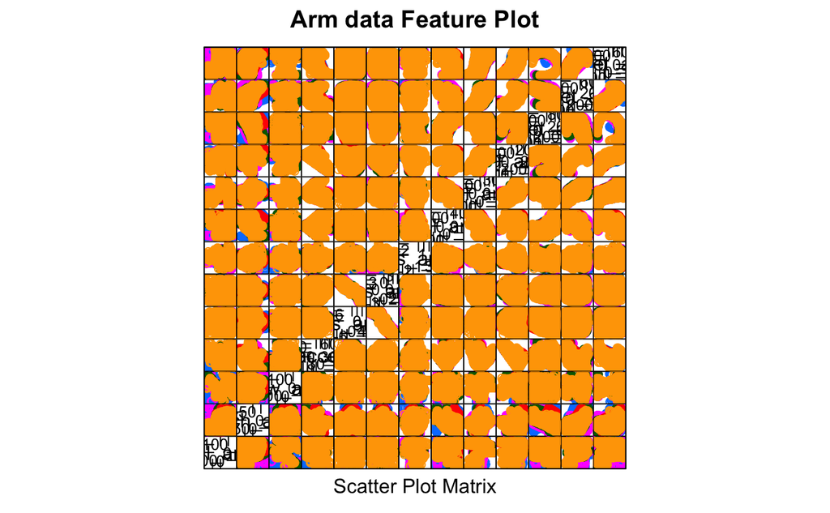

```r
featurePlot(armdata[,-14], armdata$classe, plot = "pairs", do.return = TRUE, main = "Arm data Feature Plot")
```

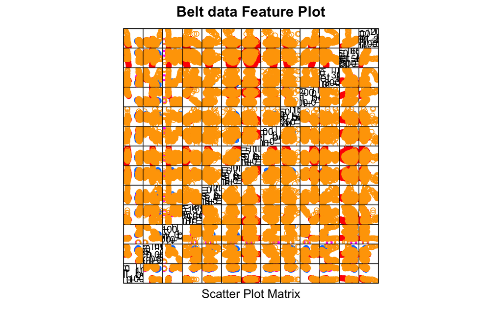

```r
featurePlot(beltdata[,-14], beltdata$classe, plot = "pairs", main = "Belt data Feature Plot")
```

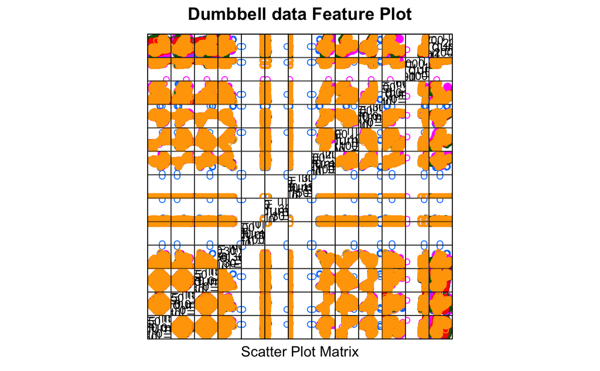

```r
featurePlot(dumbbelldata[,-14], dumbbelldata$classe, plot = "pairs", main = "Dumbbell data Feature Plot")
```

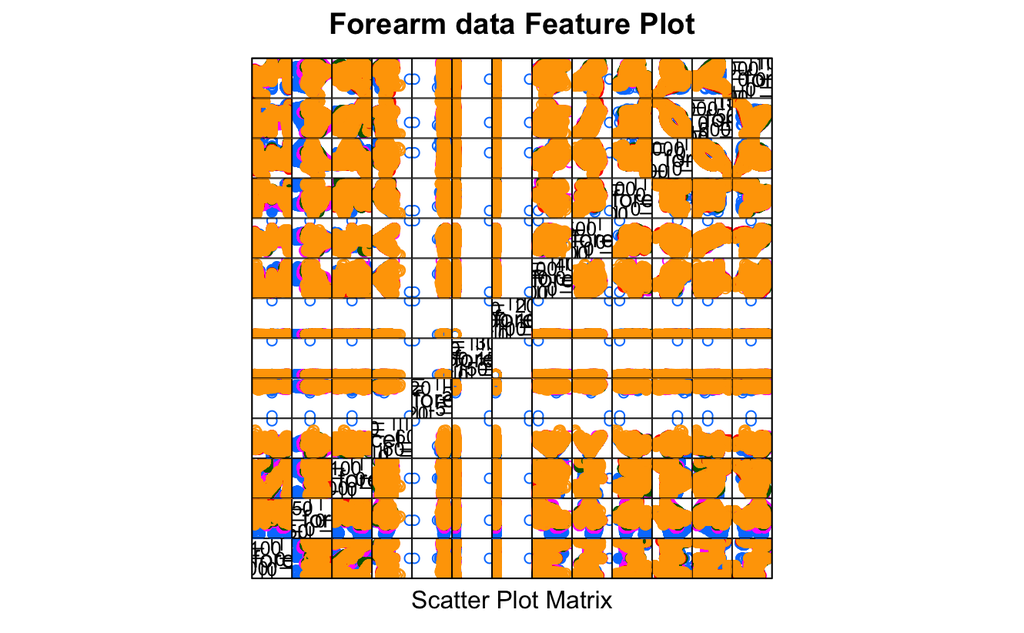

```r
featurePlot(forearmdata[,-14], forearmdata$classe, plot = "pairs", main = "Forearm data Feature Plot")
```

Selected features that have some separation between the “classe”.

```r
interesting_features <- c("roll_arm","pitch_arm","accel_arm_x","magnet_arm_x", "magnet_arm_y", "magnet_arm_z", "gyros_belt_z","magnet_belt_y","total_accel_dumbbell","gyros_dumbbell_x", "gyros_dumbbell_y", "gyros_dumbbell_z","accel_dumbbell_x","accel_dumbbell_z","magnet_dumbbell_x","magnet_dumbbell_y", "magnet_dumbbell_z", "pitch_forearm", "total_accel_forearm", "gyros_forearm_x", "gyros_forearm_y", "gyros_forearm_z" )
```

## Process Data

```r
#Make parrallel
library(parallel)
library(doParallel)
cluster <- makeCluster(detectCores() - 1) # convention to leave 1 core for OS
registerDoParallel(cluster)
# define training control
train_control<- trainControl(method="cv", number = 10, allowParallel = TRUE, seeds = list(c(1:3),c(4:6),c(7:9), c(10:12), c(13:15), c(101:103),c(104:106),c(107:109), c(110:112), c(13:15),16 ))
training %>% select(one_of(interesting_features)) %>% mutate (classe = training$classe) -> smallSet
model<- train(classe ~ ., data=smallSet,  method="rf", trControl = train_control)
#Stop parallel processing
stopCluster(cluster)
registerDoSEQ()
print(model)
```

```
Random Forest

19622 samples
   22 predictor
    5 classes: 'A', 'B', 'C', 'D', 'E'

No pre-processing
Resampling: Cross-Validated (10 fold)
Summary of sample sizes: 17659, 17659, 17660, 17659, 17662, 17660, ...
Resampling results across tuning parameters:

  mtry  Accuracy   Kappa
   2    0.9863422  0.9827220
  12    0.9869533  0.9834961
  22    0.9832325  0.9787877

Accuracy was used to select the optimal model using the largest value.
The final value used for the model was mtry = 12.
```

## Predict

```r
predict(model, testing)
```

```
 [1] B A B A A E D B A A B C B A E E A B B B
Levels: A B C D E
```